# MODELOS LINEARES GENERALIZADOS (EST082)

```
[1] "Binomial-Link(logit)"
```

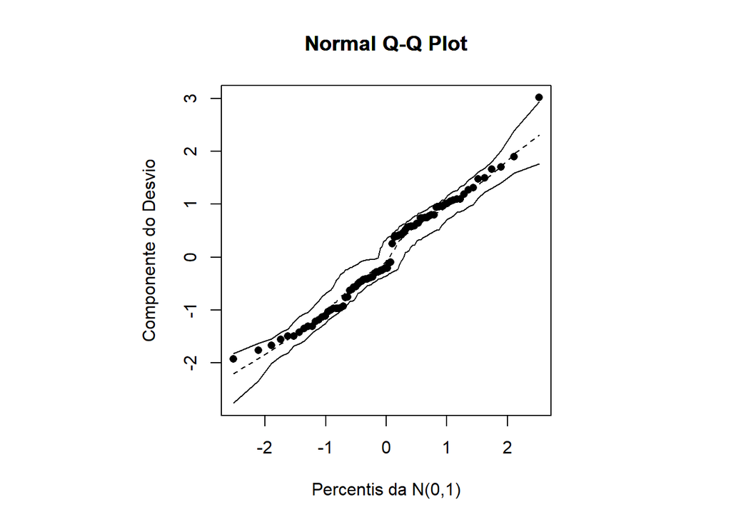

```
[1] "Binomial-Link(cauchit)"
```

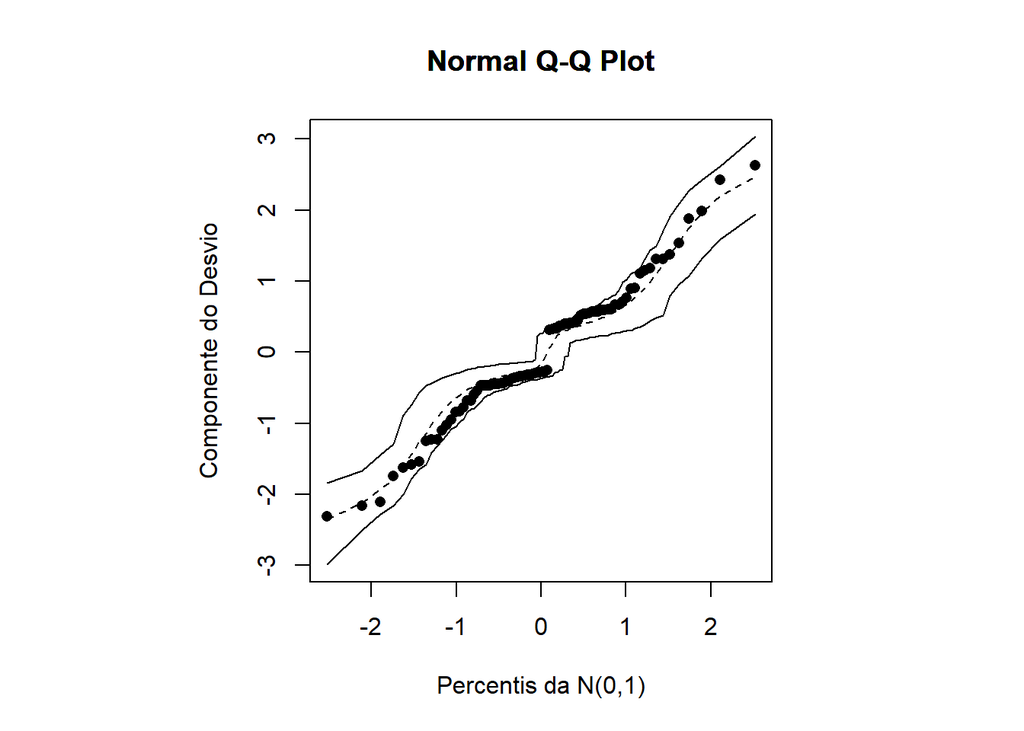

```
[1] "Binomial-Link(probit)"
```

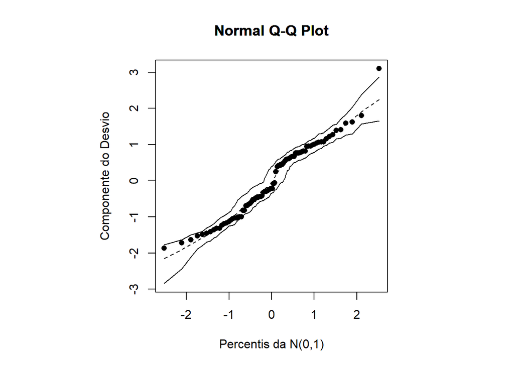

```
[1] "Binomial-Link(cloglog)"
```

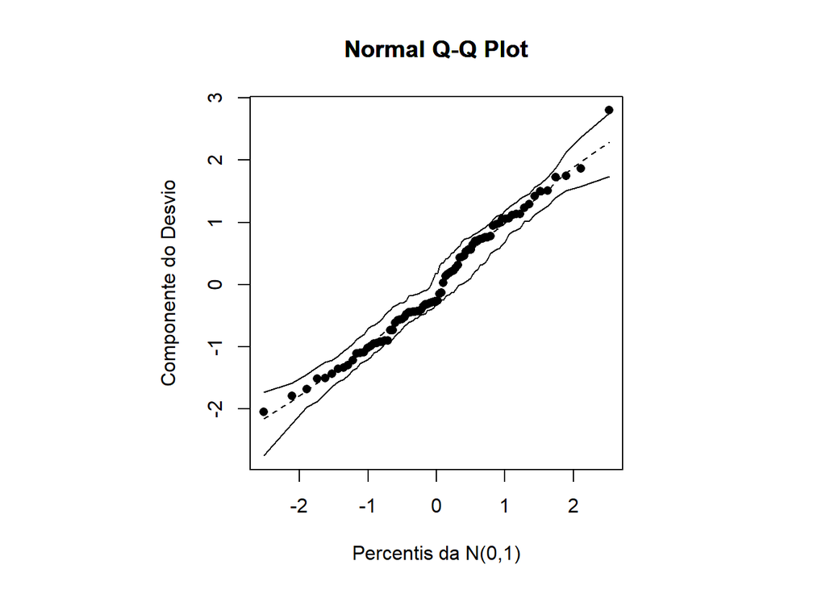

```r
binom2<-rbind(
ResultadosBinom(mat, modelo, ligacao = "logit", tipo ="envel_bino_logit",step="JAQ"),
ResultadosBinom(mat, modelo, ligacao = "cauchit", tipo ="envel_bino_cauchit",step="JAQ"),
ResultadosBinom(mat, modelo, ligacao = "probit", tipo ="envel_bino_probit",step="JAQ"),
ResultadosBinom(mat, modelo, ligacao = "cloglog", tipo ="envel_bino_cloglog",step="JAQ")
)
```

**Código**

```r
binom |>
  arrange(BIC, desc=T) |>
  knitr::kable(caption = "Melhor modelo - stepAIC", format ="pipe")
```

Melhor modelo - stepAIC

| Family | QQplot | BIC | Modelo |
| --- | --- | --- | --- |
| Binomial-Link(cauchit) | Ótimo | 99.36365 | FNDX ~ CHK + AGMN + LIV + WT + AGLP |
| Binomial-Link(cloglog) | Bom | 100.24452 | FNDX ~ CHK + AGMN + LIV + WT |
| Binomial-Link(logit) | Bom | 104.72033 | FNDX ~ CHK + AGMN + LIV + WT + AGLP |
| Binomial-Link(probit) | Bom | 105.94688 | FNDX ~ CHK + AGMN + LIV + WT + MST |

**Código**

```r
binom2 |>
  arrange(BIC, desc=T) |>
  knitr::kable(caption = "Melhor modelo - stepJAQ", format ="pipe")
```

Melhor modelo - stepJAQ

| Family | QQplot | BIC | Modelo |
| --- | --- | --- | --- |
| Binomial-Link(cauchit) | Ótimo | 99.36365 | FNDX ~ CHK + AGMN + LIV + WT + AGLP |
| Binomial-Link(cloglog) | Bom | 100.24452 | FNDX ~ CHK + AGMN + LIV + WT |
| Binomial-Link(logit) | Bom | 102.39795 | FNDX ~ CHK + AGMN + LIV + WT |
| Binomial-Link(probit) | Bom | 103.69750 | FNDX ~ CHK + AGMN + LIV + WT |

O modelo selecionado foi o com a ligação cauchit, FNDX ~ CHK + AGMN + LIV + WT + AGLP.

## Teste de adequação da função de ligação

**Código**

```r
modelo<-FNDX ~ CHK + AGMN + LIV + WT + AGLP
fit.model <- glm(modelo,family=binomial(link=cauchit))
pl2 <- predict(fit.model)^2
fit.model2<-glm(update.formula(modelo,~ . + pl2), family=binomial(link=cauchit))
testef(fit.model,fit.model2) # fit.model(H0: pl2 não significativa) #H1: pl2 é significativa
```

```
$f
[1] 2.941183

$df1
[1] 1

$df2
[1] 79

$pvalue
[1] 0.09026779
```

Não temos evidências para rejeitar $H_0$, a função de ligação “cauchit” é adequada para o modelo.

## Resíduos e Diagnóstico

**Código**

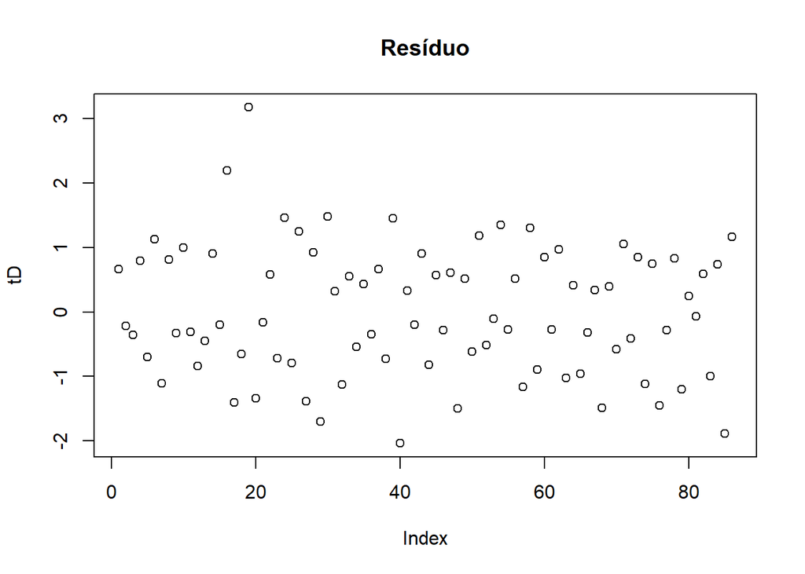

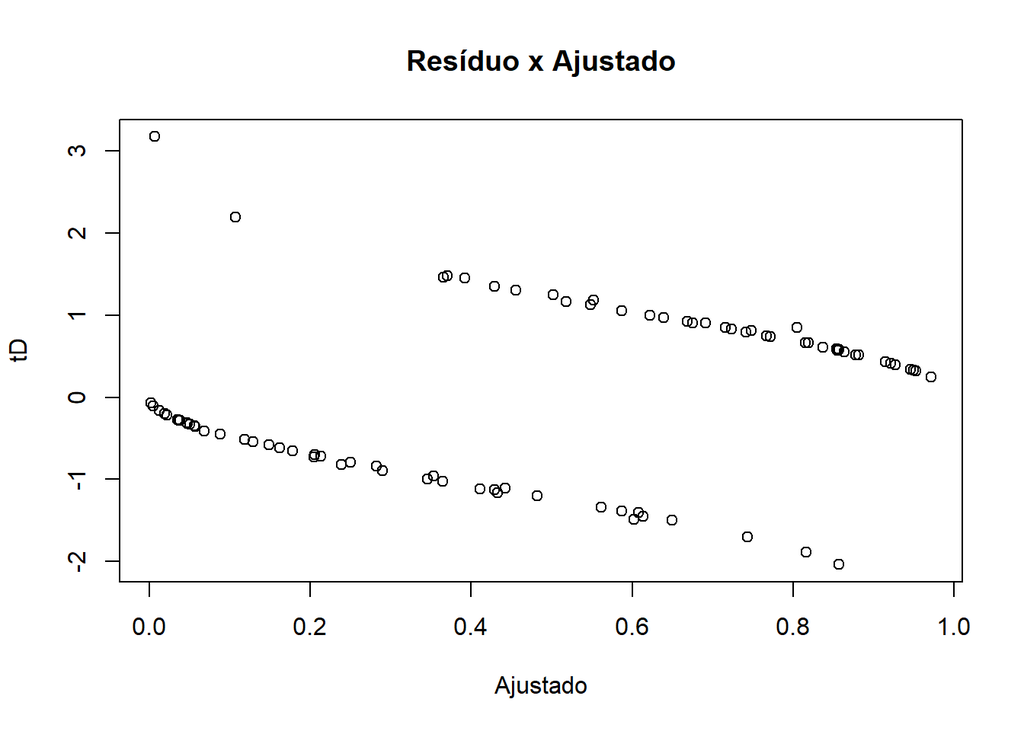

```r
modelo<-FNDX ~ CHK + AGMN + LIV + WT + AGLP
fit.model <- glm(modelo  , family=binomial(link=logit))

resul.resd<-residuos(fit.model)
```

O resíduo pelo valor ajustado não está bom, parece ter um padrão. Porém, vamos seguir com a análise de diagnóstico.

**Código**

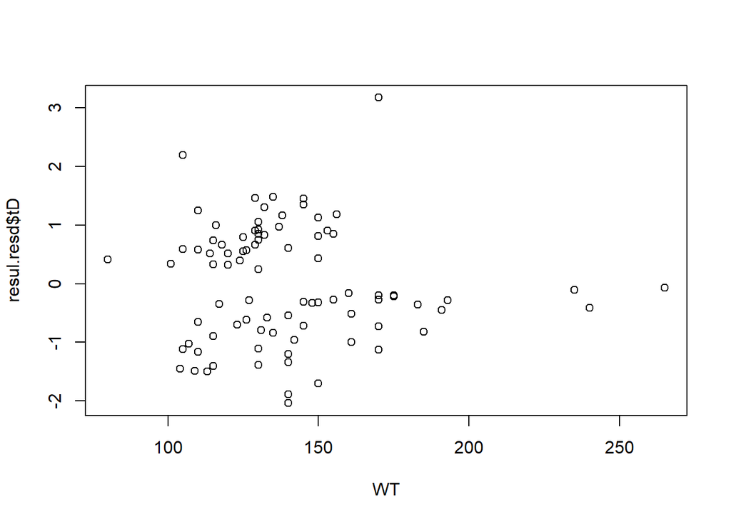

```r
plot(resul.resd$tD~WT)
```

**Código**

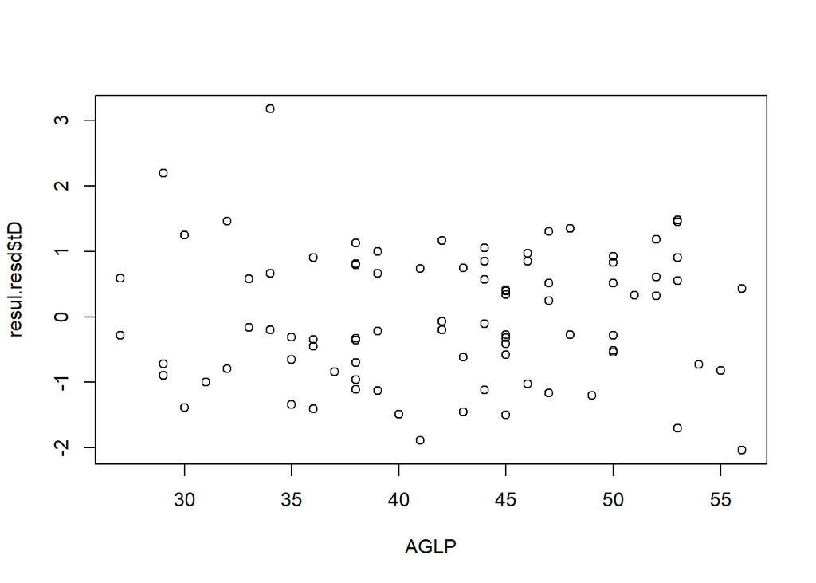

```r
plot(resul.resd$tD~AGLP)
```

**Código**

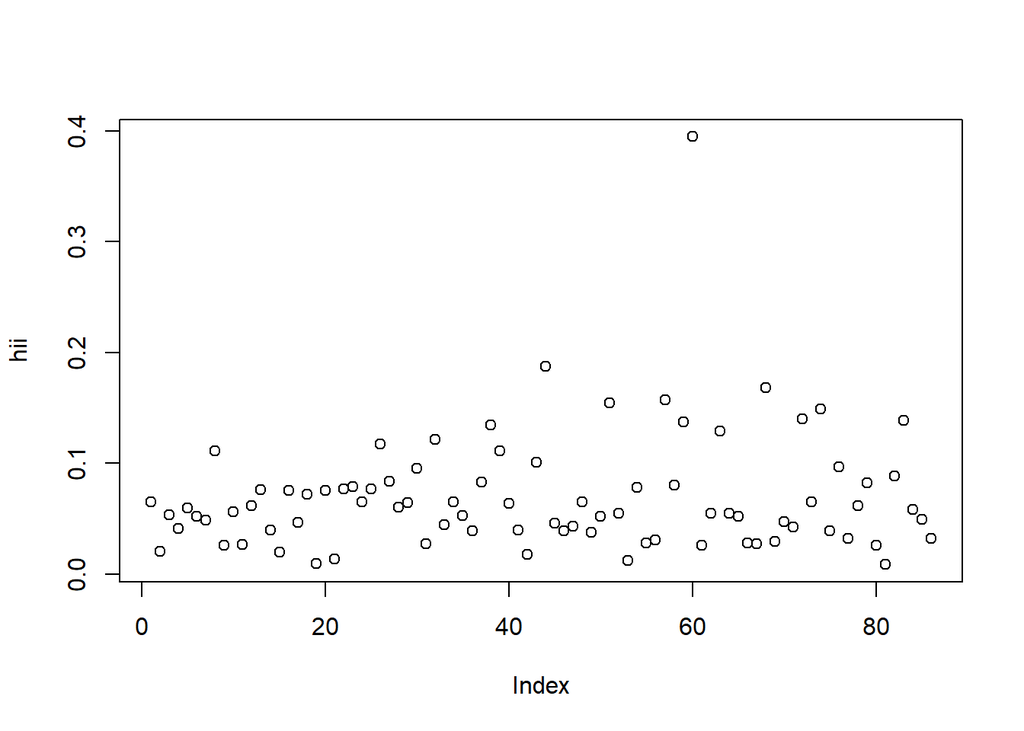

```r
plot(resul.resd$hii, ylab="hii")
```

A observação 60 é a com maior alavanca.

**Código**

```r
mat[60,c(4,7,9,11,12,13)]
```

```
# A tibble: 1 × 6
   FNDX   CHK  AGMN   LIV    WT  AGLP
  <dbl> <dbl> <dbl> <dbl> <dbl> <dbl>
1     1     2    15    11   155    46
```

**Código**

```r
summary(AGMN)
```

```
   Min. 1st Qu.  Median    Mean 3rd Qu.    Max.
   10.0    12.0    13.0    13.3    15.0    17.0
```

**Código**

```r
summary(LIV)
```

```
   Min. 1st Qu.  Median    Mean 3rd Qu.    Max.
  0.000   2.000   3.000   2.744   3.000  11.000
```

**Código**

```r
summary(WT)
```

```
   Min. 1st Qu.  Median    Mean 3rd Qu.    Max.
   80.0   120.0   132.5   139.9   150.0   265.0
```

**Código**

```r
summary(AGLP)
```

```
   Min. 1st Qu.  Median    Mean 3rd Qu.    Max.
  27.00   36.25   43.00   42.22   47.75   56.00
```

Essa observação se refere a mulher entrevistada que teve o maior número de filhos nascidos vivos.

**Código**

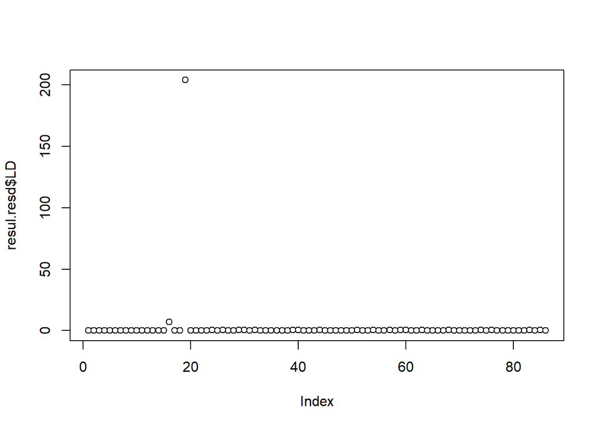

```r
plot(resul.resd$LD)
```

A observação que mais influencia na verossimilhança é a 19.

**Código**

```r
mat[19,c(4,7,9,11,12,13)]
```

```
# A tibble: 1 × 6
   FNDX   CHK  AGMN   LIV    WT  AGLP
  <dbl> <dbl> <dbl> <dbl> <dbl> <dbl>
1     1     2    10     1   170    34
```

**Código**

```r
summary(AGMN)
```

```
   Min. 1st Qu.  Median    Mean 3rd Qu.    Max.
   10.0    12.0    13.0    13.3    15.0    17.0
```

**Código**

```r
summary(LIV)
```

```
   Min. 1st Qu.  Median    Mean 3rd Qu.    Max.
  0.000   2.000   3.000   2.744   3.000  11.000
```

**Código**

```r
summary(WT)
```

```
   Min. 1st Qu.  Median    Mean 3rd Qu.    Max.
   80.0   120.0   132.5   139.9   150.0   265.0
```

**Código**

```r
summary(AGLP)
```

```
   Min. 1st Qu.  Median    Mean 3rd Qu.    Max.
  27.00   36.25   43.00   42.22   47.75   56.00
```

Essa observação se refere a mulher entrevistada que teve a idade da menarca menor.

# 16.

**Código**

```r
suppressMessages(morgan <- read_table("dados/lista3/morgan.txt",
    col_names = FALSE))
colnames(morgan)<-c("concentracao","dose","expostos","mortos")
morgan$concentracao<-as.factor(morgan$concentracao)
```

## Análise Exploratória

**Código**

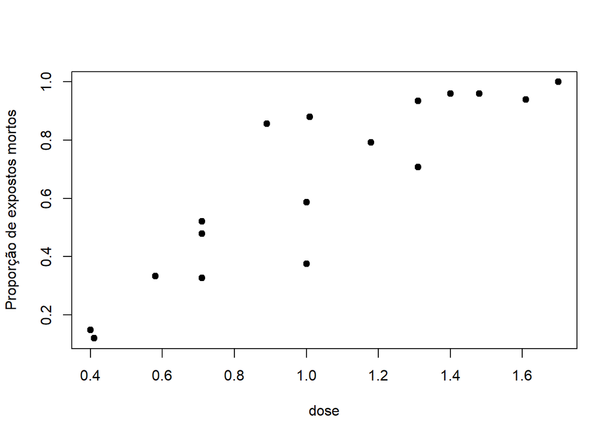

```r
suppressMessages(attach(morgan))
prop.mortos<-c(mortos/expostos)
plot(prop.mortos~dose, pch=19, ylab = "Proporção de expostos mortos")
```

**Código**

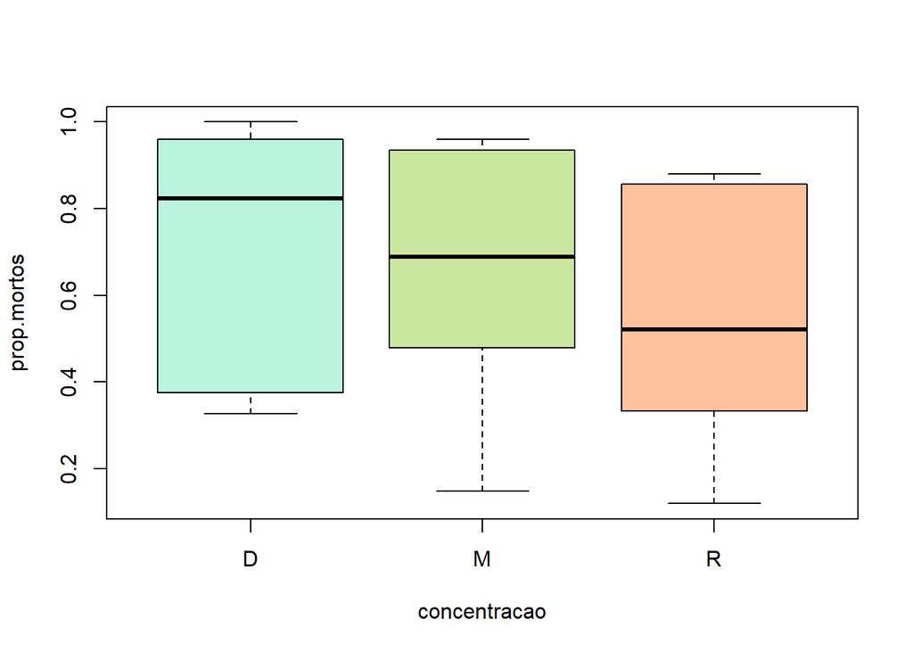

```r
boxplot(prop.mortos~concentracao, pch=19, col=cores)
```

A concentração R parece ser menos tóxica do que as outras.